# Project Proposal

8조 박지우, 신대형, 전재현, 조용수

2021-05-10

```r
#install.packages("ggplot2")    # ggplot2 패키지 설치(한번만 설치하면 됨)
#install.packages("dplyr")      # dplyr 패키지 설치(한번만 설치하면 됨)
#install.packages("GGally")     # GGally 패키지 설치(한번만 설치하면 됨)
#install.packages("gridExtra")  # gridExtra 패키지 설치(한번만 설치하면 됨)
library(ggplot2)
library(dplyr)
library(GGally)
library(gridExtra)
```

# Rmarkdown template(Title)

## 1. 데이터에 대한 설명

### Files

- train.csv : 와인의 성분 및 품질이 담긴 데이터
- test.csv : 와인의 성분이 담긴 데이터(품질을 예측할 필요)

### Columns

- index : 구분자. 말 그대로 번호를 나타내 주는 index이다.
- quality : 품질. 0에서 10 사이의 숫자로 나타내어져 있다.
- fixed acidity : 고정산. 쉽게 증발하지 않는 산을 의미
- volatile acidity : 휘발성산. 와인을 상하게 하는 효모나 박테리아에 의해 만들어지며 높은 농도(1.2~1.3g/L)일 경우 식초와 같은 불쾌한 맛을 낸다.
- citric acid : 시트르산. 와인의 신선도와 맛에 영향을 미친다.
- residual : 잔당. 발효 후 와인 속에 남아있는 당분.
- chlorides : 염화물. 와인의 짠맛을 좌우한다.
- free sulfur dioxide : 독립 이산화황. 결합되지 않은 형태의 이산화황을 의미. 와인의 보존재로 사용되는 경우가 많다.
- total sulfur dioxide : 총 이산화황. Free & Bound form Sulfur dioxide를 합친 것이다.
- density : 밀도. 와인을 마실 때의 바디감을 결정한다.알코올 도수와 설탕의 농도에 영향을 많이 받는다.
- PH : 수소이온농도. 값이 낮을수록 강한 산성임을 의미한다.
- sulphates : 황산염. 이산화황 수용액이 산화되며 만들어진 염이다. 와인의 맛을 개선하고 신선도를 유지시키며 생동감을 준다.
- alcohol : 도수. 알코올의 농도.
- type : 종류. 레드 와인인지 화이트 와인인지를 구분.

## 2. 연구가설

1. 와인의 quality는 density에 영향을 많이 받을 것이다.
2. 와인의 type별로 와인의 quality에 영향을 주는 변수가 달라질 것이다.
3. 적절한(너무 낮지도, 높지도 않은) 산도와 당도를 가진 와인이 quality가 더 높을 것이다.

## 3. 각 연구가설과 관련된 탐색적 자료 분석

```r
df = read.csv("data/train.csv", header = TRUE)    # csv file을 df라는 변수에 저장

df_red <- df %>% filter(type=='red')
df_red %>% head
```

```
##   index quality fixed.acidity volatile.acidity citric.acid residual.sugar
## 1     1       5           8.8            0.610        0.14            2.4
## 2    10       6           8.0            0.180        0.37            0.9
## 3    14       5          12.5            0.380        0.60            2.6
## 4    16       5           8.8            0.370        0.48            2.1
## 5    21       5           7.2            0.560        0.26            2.0
## 6    23       6           7.7            0.715        0.01            2.1
##   chlorides free.sulfur.dioxide total.sulfur.dioxide density   pH sulphates
## 1     0.067                  10                   42 0.99690 3.19      0.59
## 2     0.049                  36                  109 0.99007 2.89      0.44
## 3     0.081                  31                   72 0.99960 3.10      0.73
## 4     0.097                  39                  145 0.99750 3.04      1.03
## 5     0.083                  13                  100 0.99586 3.26      0.52
## 6     0.064                  31                   43 0.99371 3.41      0.57
##   alcohol type
## 1     9.5  red
## 2    12.7  red
## 3    10.5  red
## 4     9.3  red
## 5     9.9  red
## 6    11.8  red
```

```r
df_white <- df %>% filter(type=="white")
df_white %>% head
```

```
##   index quality fixed.acidity volatile.acidity citric.acid residual.sugar
## 1     0       5           5.6            0.695        0.06            6.8
## 2     2       5           7.9            0.210        0.39            2.0
## 3     3       6           7.0            0.210        0.31            6.0
## 4     4       6           7.8            0.400        0.26            9.5
## 5     5       6           6.0            0.190        0.37            9.7
## 6     6       5           6.1            0.220        0.49            1.5
##   chlorides free.sulfur.dioxide total.sulfur.dioxide density   pH sulphates
## 1     0.042                   9                   84 0.99432 3.44      0.44
## 2     0.057                  21                  138 0.99176 3.05      0.52
## 3     0.046                  29                  108 0.99390 3.26      0.50
## 4     0.059                  32                  178 0.99550 3.04      0.43
## 5     0.032                  17                   50 0.99320 3.08      0.66
## 6     0.051                  18                   87 0.99280 3.30      0.46
##   alcohol  type
## 1    10.2 white
## 2    10.9 white
## 3    10.8 white
## 4    10.9 white
## 5    12.0 white
## 6     9.6 white
```

type별로 데이터를 나누어 분석해주기 위해 red wine 데이터를 df_red에, white wine 데이터를 df_white에 저장해주었다.

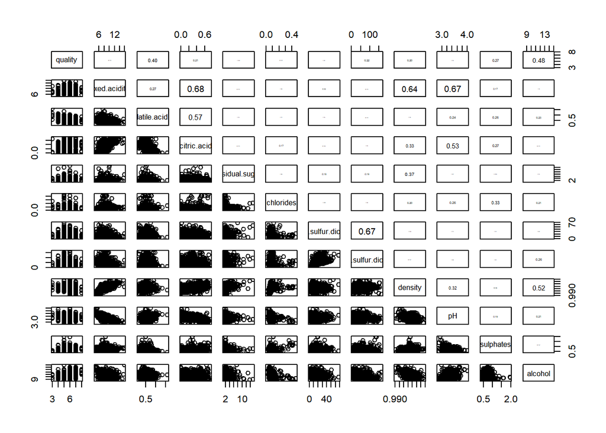

```r
# 상관계수를 출력해주기 위한 함수
panel.cor <- function(x, y, digits = 2, prefix = "", cex.cor, ...){
  usr <- par("usr"); on.exit(par(usr))
  par(usr = c(0, 1, 0, 1))
  r <- abs(cor(x, y))
  txt <- format(c(r, 0.123456789), digits = digits)[1]
  txt <- paste0(prefix, txt)
  if(missing(cex.cor)) cex.cor <- 0.8/strwidth(txt)
  text(0.5, 0.5, txt, cex = cex.cor * r)
}

pairs(df_red[2:13] %>%  sample_n(1000),
      upper.panel = panel.cor)# red wine 데이터의 변수별 산점도행렬 확인
```

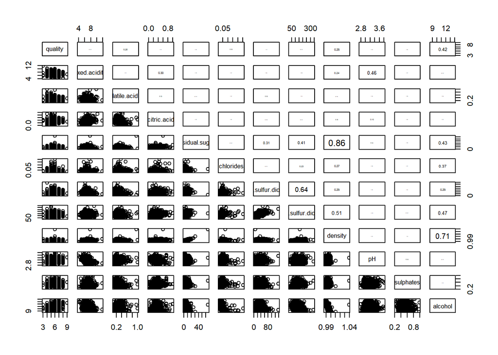

```r
pairs(df_white[2:13] %>%  sample_n(1000),
      upper.panel = panel.cor)# red wine 데이터의 변수별 산점도행렬 확인
```

두 변수 사이의 상관계수와 산점도를 표시하여 분석해보았다. red wine과 white wine 모두 quality와 가장 상관계수가 높은 변수는 alcohol임을 알 수 있다.

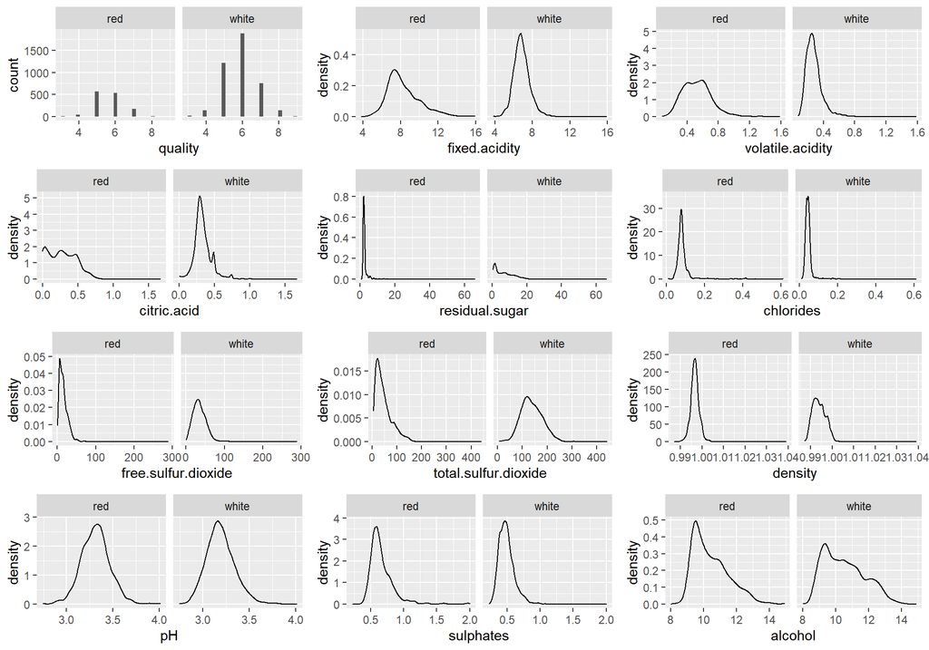

wine의 type별 분포를 히스토그램으로 나타내주었다.

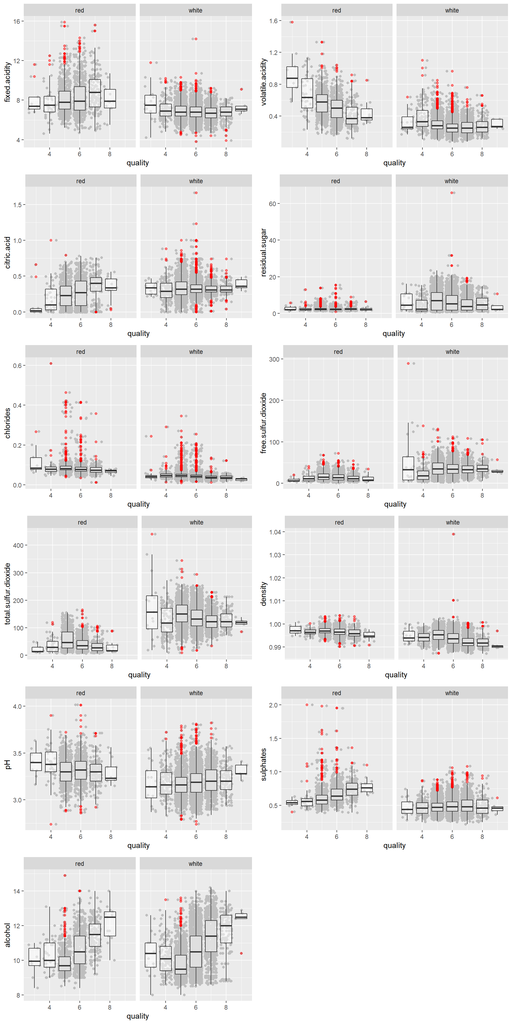

wine의 type별 분포를 boxplot으로 나타내주었다.

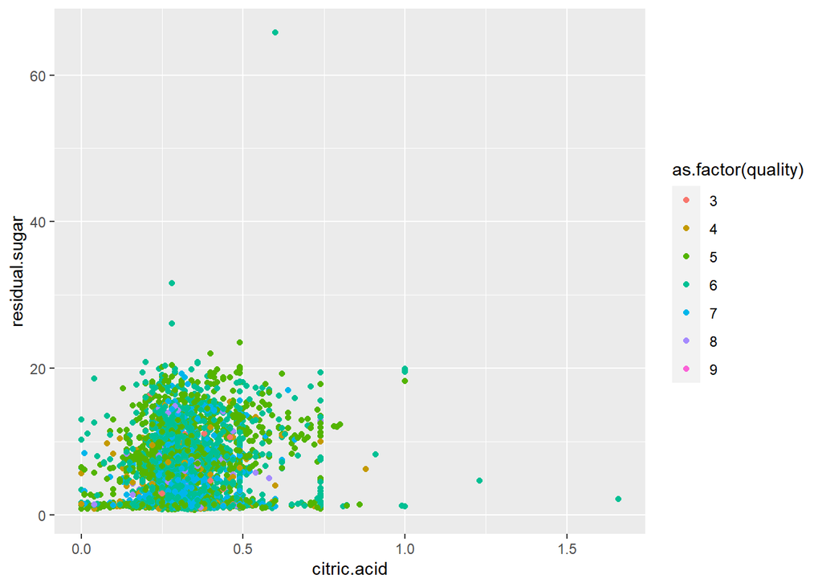

```r
df_white %>% ggplot(aes(x = citric.acid, y = residual.sugar, color=as.factor(quality))) +
  geom_point()
```

산점도 그림에 quality별로 서로 다른 color를 주어 전체적인 형태를 살펴보려고 하였으나 여러 색이 겹쳐 알아보기가 어렵다. mutate() 함수를 이용하여 새로운 new_quality column을 만들었다. (quality <=5 이면 new_quality=‘low’, quality>=7이면 new_quality=‘high’)

이후 new_quality별로 color를 다르게 주며 두 집단 사이에 유의미한 차이가 있는지 알아보았다.

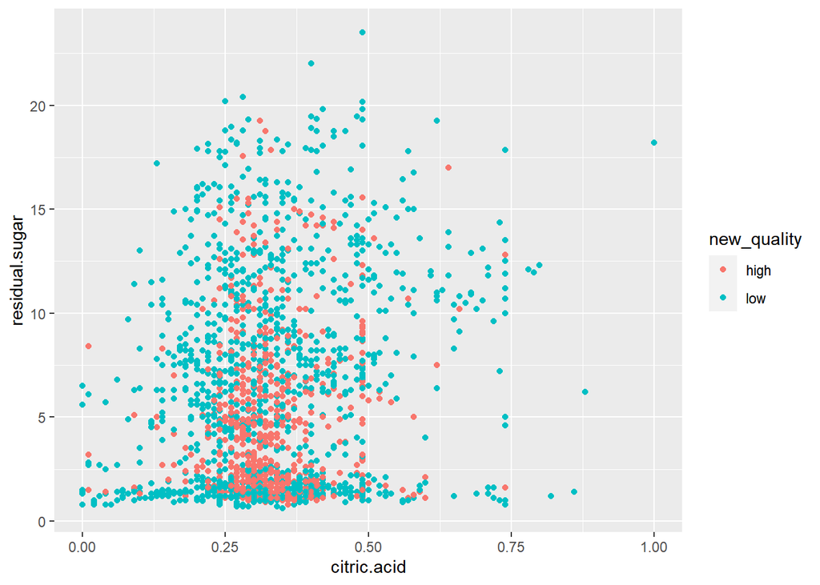

```r
df_white %>%
  filter(quality!=6) %>%
  mutate(new_quality = ifelse(quality > 6, 'high', 'low')) %>%
  ggplot(aes(x = citric.acid, y = residual.sugar, color=new_quality)) +
  geom_point()
```

우선 citric.acid는 high group이 확실히 low group보다 전체적으로 안쪽 범위에 몰려 있는 것을 확인할 수 있다.

residual.sugar도 전체적으로 high group이 편차가 더 낮은 듯 하다.